# Project Analysis for Redo Scrape Results

This notebook runs the analysis associated with the course project for MS&E 234. Very basic preliminary poking at the data collected by the scraper.

```r
################################################################################
# data import + tidying
################################################################################

indir <- 'data/derived_data'

# raw video info
read_csv(here::here(indir, params$analysis_dir, 'video_info.csv'), na = c("", -1)) %>%
  mutate_at(vars(category, dislikes, likes, views, n_comments), as.integer) -> video_info

# category id <-> category name crosswalk
category_crosswalk <- read_csv(here::here(indir, 'category_crosswalk.csv'))

# search info dataframe
read_csv(here::here(indir, params$analysis_dir, 'search_info.csv'), na = c("", -1)) %>%
  select(-recommendations) %>%
  mutate(search = stringr::str_replace_all(search, ' ', '_')) -> search_info

# add a variable for percent of likes
video_info %>%
  mutate(p_like = likes / (likes + dislikes)) -> video_info

# video degrees
degrees <- read_csv(here::here(indir, params$analysis_dir, 'vertex_degrees.csv'))

# pageranks
prs <- read_csv(here::here(indir, params$analysis_dir, 'pageranks.csv'))
```

Basic summaries across all our variables:

```r
search_info %>%
  left_join(video_info, by = 'video_id') -> search_w_info

search_w_info %>%
  rename_all(list(~ stringr::str_replace(., "_", "."))) %>%
  select(views, likes, dislikes, n.comments) %>%
  summarise_all(list(min = ~min(., na.rm = TRUE),
                     median = ~median(., na.rm = TRUE),
                     max = ~max(., na.rm = TRUE),
                     mean = ~mean(., na.rm = TRUE),
                     sd = ~sd(., na.rm = TRUE))) -> summary_stats

summary_stats %>%
  gather(stat, val) %>%
  tidyr::separate(stat, into = c("var", "stat"), sep = "_", extra = "merge") %>%
  spread(stat, val) %>%
  select(Variable = var, mean, median, min, max, sd) %>%
  kable(format = "latex",
        caption = "Summaries",
        booktabs = TRUE,
        digits = 2) %>%
  kable_styling()
```

Now asking the question: did any features of our videos change (on average) as we traversed the trees?

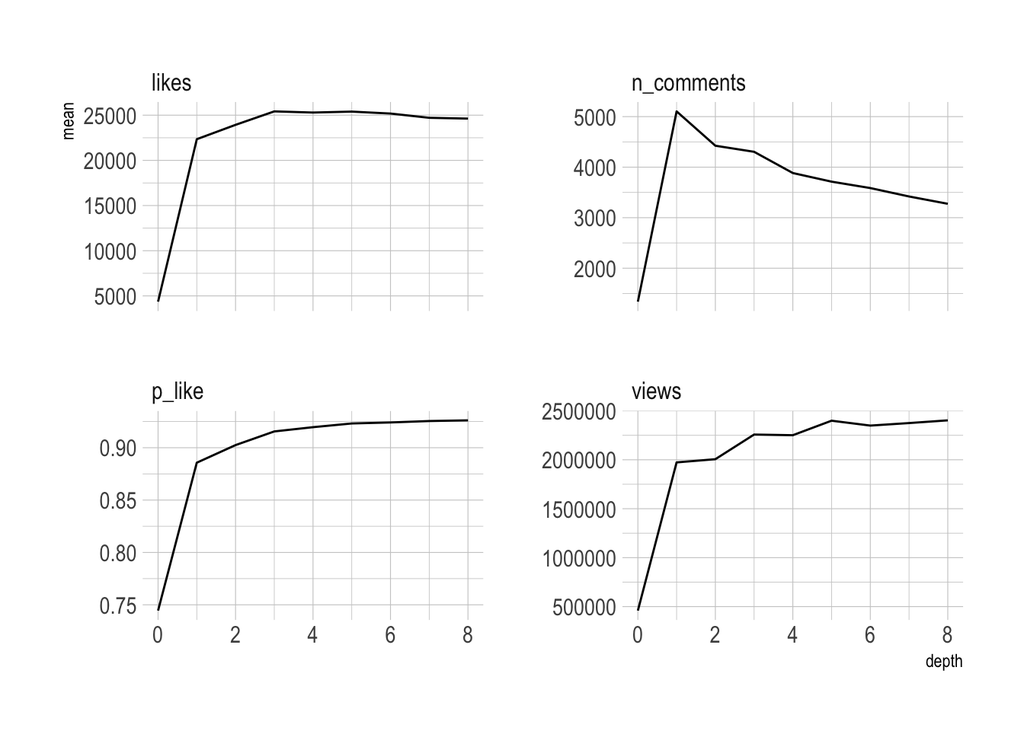

```r
# get average statistics by search depth
search_w_info %>%
  group_by(depth) %>%
  summarise_at(vars(likes, n_comments, views, p_like),
               function(x) mean(x, na.rm = TRUE)) %>%
  gather(stat, mean, -depth) -> mean_by_depth

search_w_info %>%
  group_by(depth) %>%
  summarise_at(vars(likes, n_comments, views, p_like),
               function(x) sd(x, na.rm = TRUE) / sqrt(length(x))) %>%
  gather(stat, se, -depth) -> se_by_depth

search_w_info %>%
  group_by(depth) %>%
  summarise_at(vars(likes, n_comments, views, p_like),
               function(x) sd(x, na.rm = TRUE)) %>%
  gather(stat, sd, -depth) -> sd_by_depth

mean_by_depth %>%
  left_join(se_by_depth, by = c('depth', 'stat')) %>%
  left_join(sd_by_depth, by = c('depth', 'stat')) -> stats_by_depth

stats_by_depth %>%
  ggplot(aes(depth, mean)) +
  geom_line() +
  facet_wrap(~ stat, scales="free_y")
```

This gives us an overview. For the sake of less ugly plots let’s make these individually

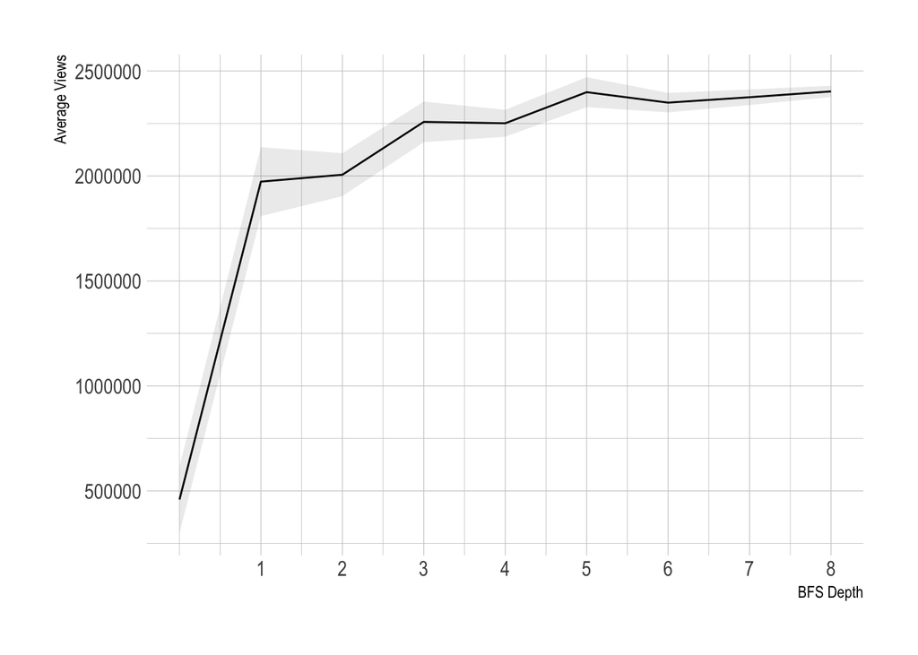

```r
stats_by_depth %>%
  filter(stat == "views") %>%
  ggplot(aes(depth, mean)) +
  geom_line() +
  geom_ribbon(aes(ymin=mean-se, ymax=mean+se), alpha=0.1) +
  ylab("Average Views") +
  xlab("BFS Depth") +
  scale_x_continuous(breaks=1:8)
```

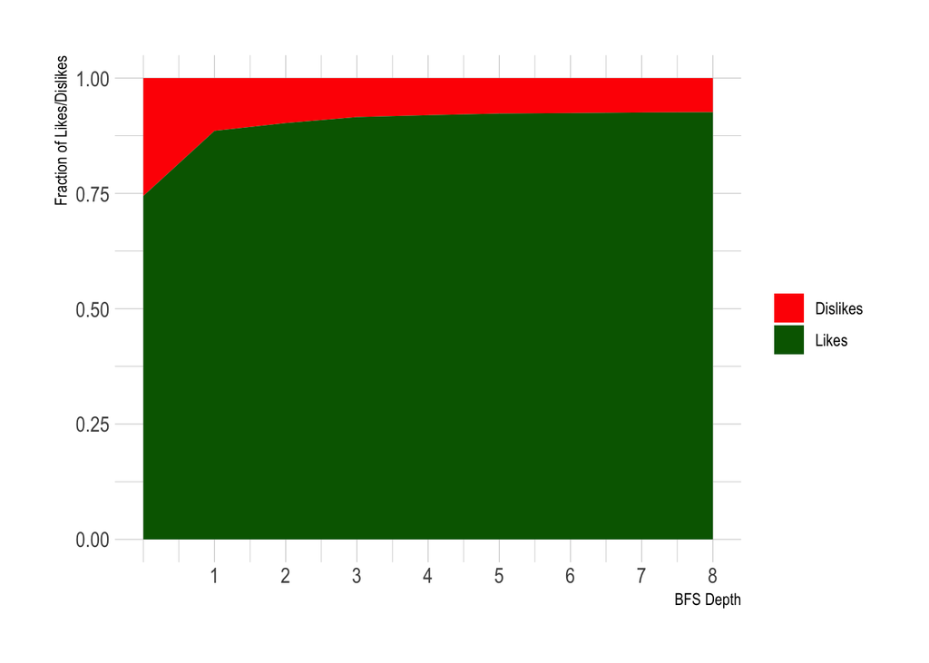

```r
stats_by_depth %>%
  filter(stat == "p_like") %>%
  mutate(mean = 1 - mean,
         stat = "p_dislike") %>%
  select(-se) -> dislikes

stats_by_depth %>%
  bind_rows(dislikes) %>%
  filter(stat %in% c("p_like", "p_dislike")) %>%
  mutate(stat = ifelse(stat == "p_like", "Likes", "Dislikes")) %>%
  ggplot(aes(depth, mean, fill=stat)) +
  geom_area() +
  ylab("Fraction of Likes/Dislikes") +
  xlab("BFS Depth") +
  scale_fill_manual(name = "", values = c("red", "darkgreen")) +
  scale_x_continuous(breaks=1:8)
```

What happens to our categories as we go *deeperrr*?

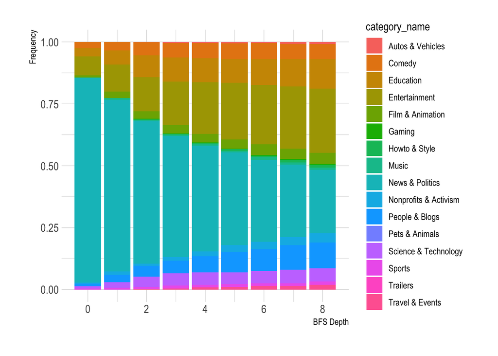

```r
search_w_info %>%
  left_join(category_crosswalk, by = c('category' = 'category_id')) %>%
  mutate_at("category_name", as.factor) %>%
  group_by(depth, category_name) %>%
  summarise(n = n()) %>%
  mutate(category_freq = n / sum(n)) -> category_freq

category_freq %>%
  group_by(depth) %>%
  summarise(sum = sum(category_freq)) -> tst

category_freq %>%
  ggplot(aes(depth, category_freq, fill = category_name)) +
  geom_col() +
  xlab("BFS Depth") +
  ylab("Frequency")
```

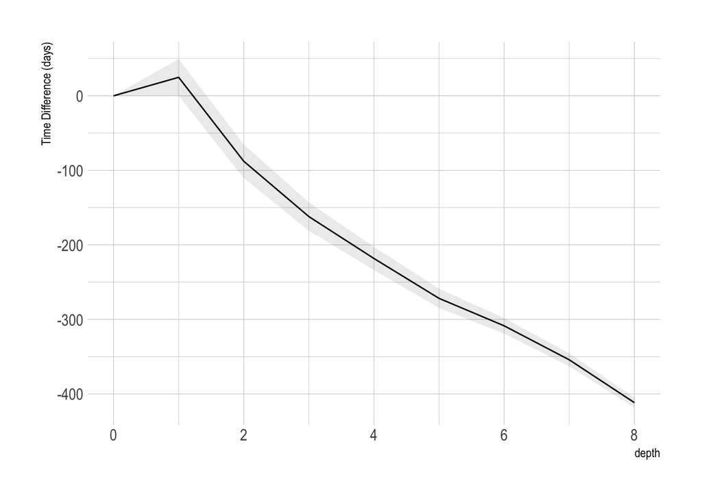

```r
# post date by depth
search_w_info %>%
  group_by(search) %>%
  mutate(root_date = postdate[which(depth == 0)]) %>%
  mutate(time_diff = difftime(postdate, root_date, units="days")) %>%
  ungroup() %>%
  select(depth, search, time_diff) -> time_diffs

time_diffs %>%
  group_by(depth) %>%
  summarize(mean = mean(time_diff, na.rm = TRUE),
           se = sd(time_diff, na.rm = TRUE) / sqrt(length(time_diff))) %>%
  ggplot(aes(depth, mean)) +
  geom_line() +
  geom_ribbon(aes(ymin=mean-se, ymax=mean+se), alpha=0.1) +
  ylab("Time Difference (days)")
```

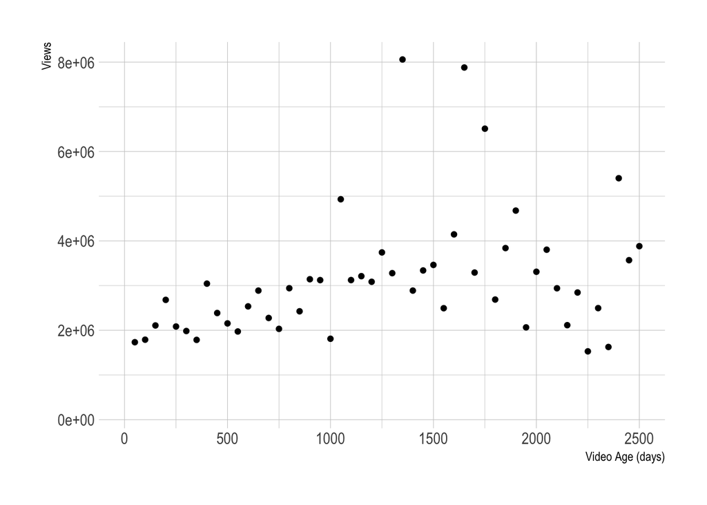

```r
search_w_info %>%
  mutate(video_age = as.numeric(difftime(as.Date("2019-03-13", format="%Y-%m-%d"), postdate, units="days"))) %>%
  mutate(age_bin = cut(video_age, seq(0, 4500, 50), labels=FALSE)) %>%
  mutate(age_bin = age_bin * 50) %>%
  group_by(age_bin) %>%
  summarise(mean = mean(views, na.rm = TRUE),
            se = sd(views, na.rm = TRUE) / sqrt(length(views))) %>%
  ungroup() %>%
  ggplot(aes(age_bin, mean)) +
  geom_point() +
  ylab("Views") +
  xlab("Video Age (days)") +
  xlim(c(0, 2500))
```

# Graphy things

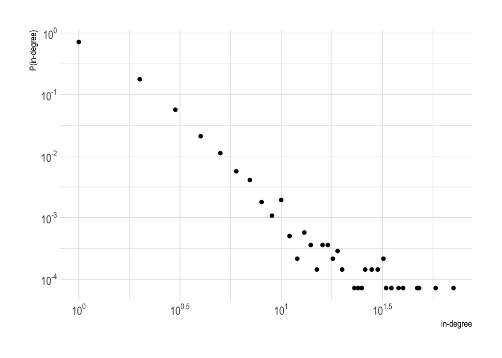

```r
# degree distribution
n_videos <- nrow(degrees)

degrees %>%
  group_by(in_deg) %>%
  summarise(p = n() / n_videos) %>%
  ggplot(aes(in_deg, p)) +
  geom_point() +
  scale_y_log10(breaks = scales::trans_breaks("log10", function(x) 10^x),
                labels = scales::trans_format("log10", scales::math_format(10^.x))) +
  scale_x_log10(breaks = scales::trans_breaks("log10", function(x) 10^x),
                labels = scales::trans_format("log10", scales::math_format(10^.x))) +
  ylab("P(in-degree)") +
  xlab("in-degree")
```

Look at characteristics by in-degree. First: what are the videos with the highest in-degree?

```r
degrees %>%
  select(video_id, in_deg) %>%
  top_n(10, in_deg) %>%
  arrange(-in_deg) %>%
  left_join(video_info %>% select(video_id, title, channel), by = "video_id") %>%
  kable(format = "latex",
        caption = "Top Videos by In-Degree",
        col.names = c("Video", "In-Degree", "Title", "Channel"),
        booktabs = TRUE,
        digits = 2) %>%
  kable_styling(latex_options = c("scale_down"))
```

How do things vary with in-degree?

```r
degrees %>%
  left_join(video_info, by = "video_id") %>%
  select(-category, -channel, -description, -postdate, -title, -out_deg) %>%
  gather(stat, val, -c("video_id", "in_deg")) %>%
  filter(!is.na(val)) -> deg_stats_long

deg_stats_long %>%
  group_by(in_deg, stat) %>%
  dplyr::summarize(mean = mean(val, na.rm = TRUE),
            se = sd(val, na.rm = TRUE) / sqrt(length(val)),
            count = n()) -> deg_stats
```

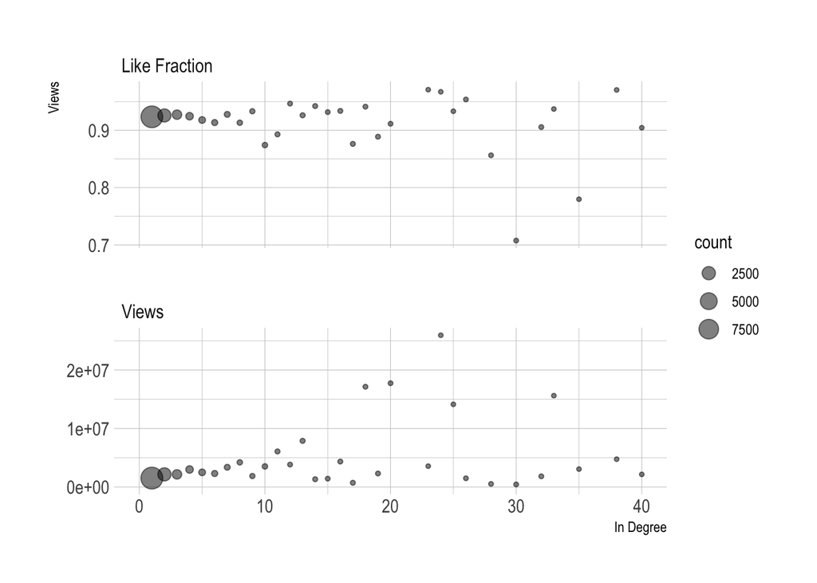

```r
deg_stats %>%
  filter(stat %in% c("views", "p_like")) %>%
  mutate(stat = case_when(stat == "views" ~ "Views",
                          stat == "p_like" ~ "Like Fraction")) %>%
  ggplot(aes(in_deg, mean, size = count)) +
  geom_point(alpha = 0.5) +
  facet_wrap(~stat, nrow=2, scales = "free_y") +
  xlim(c(0, 40)) +
  ylab("Views") +
  xlab("In Degree")
```

How do things vary with PageRanks?

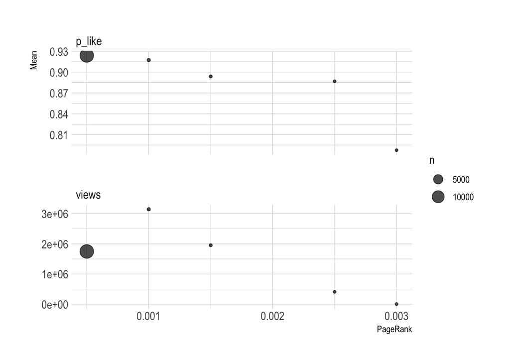

```r
deg_stats_long %>%
  filter(stat %in% c("views", "p_like")) %>%
  left_join(prs, by = 'video_id') %>%
  mutate(pagerank = cut(pagerank, seq(0, 0.005, 0.0005), labels = FALSE) * 0.0005) %>%
  group_by(pagerank, stat) %>%
  summarise(val = mean(val, na.rm = TRUE),
            n = n()) %>%
  ggplot(aes(pagerank, val, size = n)) +
  geom_point(alpha=0.7) +
  facet_wrap(~stat, nrow=2, scales = "free_y") +
  xlab("PageRank") +
  ylab("Mean")
```

# Polarization

The motivation for this project was to get a sese of the polarization of the content that the Youtube recommendation engine points towards. I’ve scraped a few websites and compiled a list of media outlets / political sources and their political leaning: left, center, or right. I want to make a figure / do some analysis that captures the probability you land on a left- or right-leaning video conditional on your starting query – I seeded my scrapes with the names of left- or right-leaning politicians. There are two ways I might condition:

1. P(landing on bias *b* at level *d* | started with *b* leaning query)
2. P(landing on bias *b* at level *d* | started by *b* leaning video)

```r
# import the channel-leaning information
channel_leanings <- readr::read_csv(here::here(indir, params$analysis_dir, 'channel_classification.csv'))

# make a query <-> party affiliation crosswalk
dems <- c("jim clyburn", "kagan", "aoc", "susan rice", "john podesta", "sotomayor", "krysten sinema",
          "john lewis", "pelosi", "ruth bader ginsburg", "gavin newsom", "loretta lynch", "beto orourke",
          "schumer", "democrats", "maxine waters", "john kelly", "david axelrod", "john kerry", "eric holder",
          "dick durbin", "rahm emanuel", "biden", "obama", "clinton", "bernie", "cory booker", "tim geithner",
          "kamala harris", "gillibrand", "dan pfeiffer")

tibble(query = dems) %>%
  mutate(query_leaning = "L") -> l_queries

reps <- c("trump", "sarah huckabee sanders", "mike pompeo", "william barr", "wilbur ross", "pence", "ted cruz",
          "mick mulvaney", "rick perry", "scott pruitt", "mcconnell", "rex tillerson", "ben carson", "kavanaugh",
          "john cornyn", "paul ryan", "susan collins", "james mattis", "lindsay graham", "kevin mccarthy",
          "steve mnuchin", "betsy devos", "jeff sessions", "kushner")

tibble(query = reps) %>%
  mutate(query_leaning = 'R') -> r_queries

query_classifications <- bind_rows(l_queries, r_queries)

# join the query and channel classifications into the saerch info dataframe
search_w_info %>%
  mutate_at("channel", tolower) %>%
  left_join(channel_leanings, by = 'channel') %>%
  left_join(query_classifications, by = 'query') %>%
  select(search, query, video_id, depth, channel, leaning, query_leaning) -> search_leanings
```

```r
# print out the table of queries and classifications
query_classifications %>%
  arrange(query) %>%
  kable(format = "latex",
        caption = "Queries and Leanings",
        booktabs = TRUE,
        digits = 2,
        col.names = c("Query", "Leaning"),
        longtable = TRUE) %>%
  kable_styling()
```

First look at the counts of R vs L vs C leaning videos. Looks like we have mostly left leaning videos.

```r
search_leanings %>%
  count(leaning) %>%
  mutate(freq = n / sum(n)) -> leaning_freqs

search_leanings %>%
  distinct(video_id, leaning) %>%
  count(leaning) %>%
  mutate(frac_videos = n / sum(n)) %>%
  rename(n_videos = n) -> video_leaning_counts

search_leanings %>%
  distinct(channel, leaning) %>%
  count(leaning) %>%
  mutate(frac_channels = n / sum(n)) %>%
  rename(n_channels = n) -> channel_leaning_counts

channel_leaning_counts %>%
  left_join(video_leaning_counts, by = 'leaning') %>%
  kable(format = "latex",
        caption = "Summaries",
        booktabs = TRUE,
        digits = 2,
        col.names = c("Leaning", "No. Channels", "Frac. Channels", "No. Videos", "Frac. Videos")) %>%
  kable_styling()
```

What are the frequencies for just the base videos?

```r
search_leanings %>%
  filter(depth == 0) %>%
  count(leaning) %>%
  mutate(freq = n / sum(n)) -> base_leanings

base_leanings %>%
  kable(format = "latex",
        caption = "Summaries",
        booktabs = TRUE,
        digits = 2,
        col.names = c("Leaning", "Count", "Proportion")) %>%
  kable_styling()
```

What sorts of queries return the most R vs L leaning videos?

```r
search_leanings %>%
  filter(!is.na(leaning)) %>%
  group_by(query, leaning) %>%
  summarise(n = n()) %>%
  mutate(freq = n / sum(n)) -> query_tree_leanings

query_tree_leanings %>%
  filter(leaning == 'L') %>%
  select(query, freq) %>%
  top_n(10) %>%
  arrange(-freq)
```

| query | freq |
| --- | --- |
| betsy devos | 0.87096774 |
| cory booker | 0.83173996 |
| rex tillerson | 0.80526316 |
| jeff sessions | 0.77051672 |
| john kerry | 0.75979112 |
| kyrsten sinema | 0.74587912 |
| dan pfeiffer | 0.69911504 |
| kushner | 0.69547325 |
| white house | 0.66731518 |
| john kelly | 0.66528354 |

[output cut: 50 more lines]

```r
query_tree_leanings %>%
  filter(leaning == 'R') %>%
  select(query, freq) %>%
  top_n(10) %>%
  arrange(-freq)
```

| query | freq |
| --- | --- |
| susan rice | 0.69880823 |
| mike pompeo | 0.68164062 |
| susan collins | 0.66117647 |
| loretta lynch | 0.65130760 |
| lindsay graham | 0.64194373 |
| pelosi | 0.63753724 |
| politics | 0.57307692 |
| william barr | 0.54393939 |
| aoc | 0.53753754 |
| mueller | 0.53584447 |

[output cut: 50 more lines]

Plot political leaning of channels by depth:

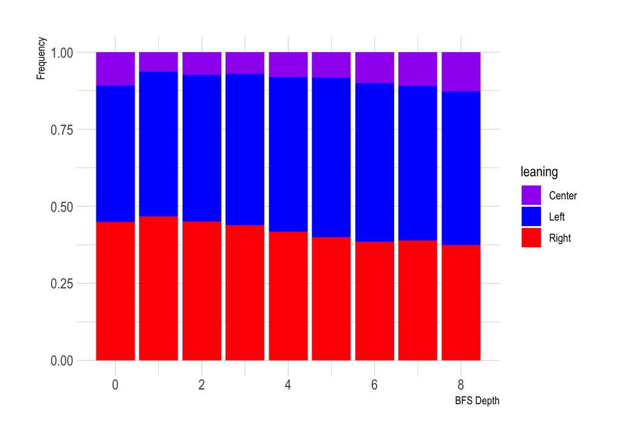

```r
search_leanings %>%
  filter(!is.na(leaning)) %>%
  group_by(depth, leaning) %>%
  summarise(n = n()) %>%
  mutate(freq = n / sum(n)) -> leaning_by_depth

leaning_by_depth %>%
  mutate(leaning = case_when(leaning == "C" ~ "Center",
                             leaning == "L" ~ "Left",
                             leaning == "R" ~ "Right")) %>%
  ggplot() +
  geom_col(aes(depth, freq, fill = leaning)) +
  scale_fill_manual(values = c("purple", "blue", "red")) +
  ylab("Frequency") +
  xlab("BFS Depth")
```

Breaking this up by leaning of the query:

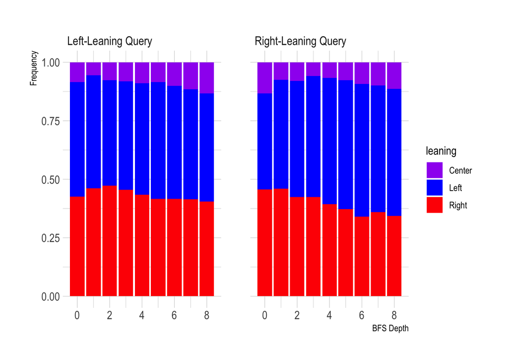

```r
search_leanings %>%
  filter(!is.na(leaning), !is.na(query_leaning)) %>%
  group_by(query_leaning, depth, leaning) %>%
  summarise(n = n()) %>%
  mutate(freq = n / sum(n)) %>%
  ungroup() %>%
  mutate(query_leaning = ifelse(query_leaning == 'L', 'Left-Leaning Query', 'Right-Leaning Query'),
         leaning = case_when(leaning == "C" ~ "Center",
                             leaning == "L" ~ "Left",
                             leaning == "R" ~ "Right")) %>%
  ggplot() +
  geom_col(aes(depth, freq, fill = leaning)) +
  scale_fill_manual(values = c("purple", "blue", "red")) +
  facet_wrap(~ query_leaning) +
  ylab("Frequency") +
  xlab("BFS Depth")
```

Not a lot of action, although this may be a result of queries not containing a ton of information about the polarization of the initial video. Let’s look instead at how political bias evolves by depth, broken up by the leaning of the seed (root) video.

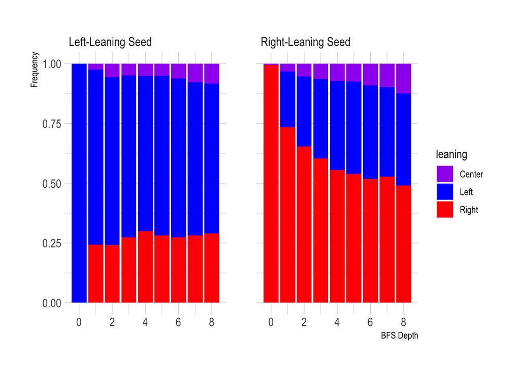

```r
search_leanings %>%
  group_by(search) %>%
  mutate(seed_leaning = leaning[which.min(depth)]) %>%
  ungroup() %>%
  filter(seed_leaning %in% c('L', 'R'),
         !is.na(leaning)) %>%
  group_by(seed_leaning, depth, leaning) %>%
  summarise(n = n()) %>%
  mutate(freq = n / sum(n)) %>%
  ungroup() %>%
  mutate(seed_leaning = ifelse(seed_leaning == 'L', 'Left-Leaning Seed', 'Right-Leaning Seed'),
       leaning = case_when(leaning == "C" ~ "Center",
                           leaning == "L" ~ "Left",
                           leaning == "R" ~ "Right")) %>%
  ggplot() +
  geom_col(aes(depth, freq, fill = leaning)) +
  scale_fill_manual(values = c("purple", "blue", "red")) +
  facet_wrap(~ seed_leaning) +
  ylab("Frequency") +
  xlab("BFS Depth")
```

# Isolation Index

```r
# get the conservative and liberal counts for each channel. Consider each tree as a search
# by a single user. The user's political leaning is defined as the leaning of the very first (root) video
# in the tree.
search_leanings %>%
  group_by(search) %>%
  mutate(seed_leaning = leaning[which.min(depth)]) %>%
  ungroup() %>%
  filter(seed_leaning %in% c('L', 'R')) %>%
  mutate(seed_leaning = factor(seed_leaning, levels=c('L', 'R'))) %>%
  count(channel, seed_leaning, .drop = FALSE) -> leaning_visit_counts

# get the conservative and liberal shares for each channel
leaning_visit_counts %>%
  tidyr::spread(seed_leaning, n) %>%
  rename(n_l = L, n_r = R) %>%
  mutate(p_l = (n_l) / (n_l + n_r),
         p_r = (n_r) / (n_l + n_r)) -> leaning_info

# get the total number of liberal/conservative seed videos.
search_leanings %>%
  group_by(search) %>%
  mutate(seed_leaning = leaning[which.min(depth)]) %>%
  ungroup() %>%
  count(seed_leaning) -> total_visits_by_leaning

n_cons_visits <- total_visits_by_leaning %>% filter(seed_leaning == 'R') %>% pull(n)
n_lib_visits <- total_visits_by_leaning %>% filter(seed_leaning == 'L') %>% pull(n)

leaning_info %>%
  summarise(isolation = sum((p_r * n_r) / n_cons_visits, na.rm = TRUE)) %>%
  pull(isolation) -> cons_exposure

leaning_info %>%
  summarise(isolation = sum((p_l * n_r)/n_lib_visits, na.rm = TRUE)) %>%
  pull(isolation) -> lib_exposure

isolation_index = cons_exposure - lib_exposure
```

```r
channel_leanings %>%
  arrange(channel) %>%
  kable(format = "latex",
        caption = "Channels and Classifications",
        booktabs = TRUE,
        col.names = c("Channel", "Bias"),
        digits = 2,
        longtable = TRUE) %>%
  kable_styling()
```